# NMDS_Permanova_Abundance

Estephe Kana, Eugeni Belda & Edi Prifti

2023-10-18

### Loading packages

```r
library(readr) # for data import
library(momr) # for normalizing, visualizing and microbiome analyses
library(ggplot2) # for plots
library(gridExtra) # for multiple plots
library(vegan) # for ecological analyses
library(viridis) # for colour maps
library(stats) # for euclidean distance computation
library(predomics) # loading predomics
library(patchwork) # to display multiples graphs in the same figure
library(dplyr)
library(plyr)
library(ggrepel)
library(labdsv) # for Indicator Species Analysis
```

## NMDS (Non-metric multidimensional distance scaling) on community species, indval species, terinter species and bininter species

- The first nmds plot for all community species shows less separate set of species for stations
- The second nmds plot for the 44 indicator species obtained using indval method shows a better clustering of species accross stations
- The third and fourth plots seems to be better than the second also

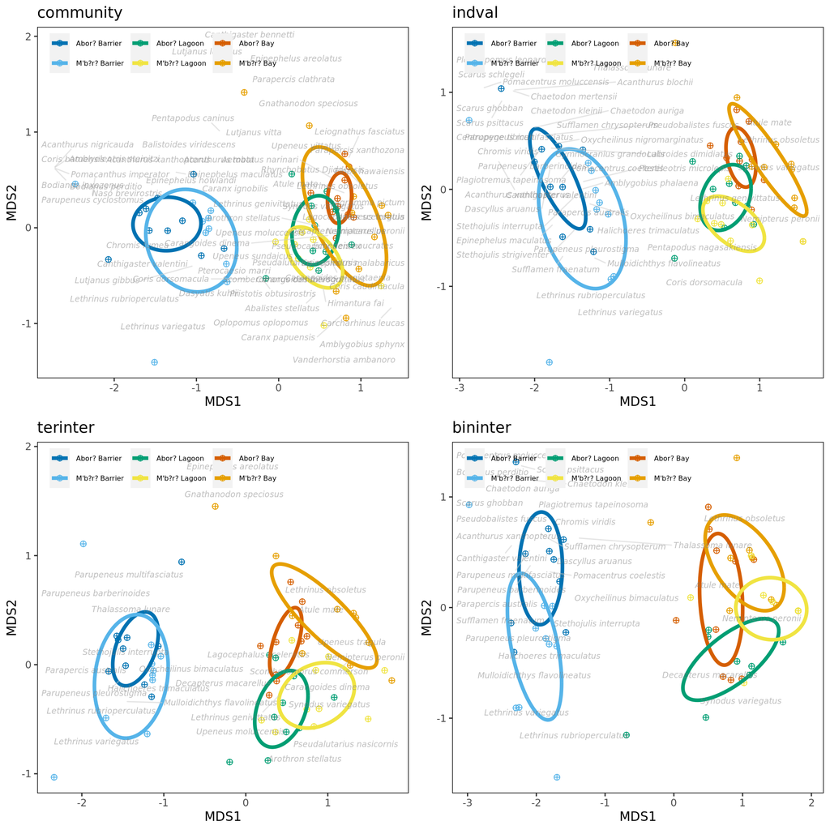

```r
# load the data
load(file="/data/projects/aime/analyses/metabarcoding/4.data_video_analysis/video_data_object.rda")

# compute nmds on community data
nmds.community= metaMDS(t(sm$X), distance = "bray")

# compute nmds on Indval species data
df1 <- as.data.frame(read_csv("/data/projects/aime/analyses/metabarcoding/4.data_video_analysis/InValSpecies_video_data.csv", show_col_types = FALSE))

## select data for indval species and compute nmds
indval_data = filter(df1, IsIndSpec == 1)
indval_data = sm$X[rownames(sm$X) %in% indval_data$Species, ]
nmds.indval= metaMDS(t(indval_data), distance = "bray")
nmds.indval.scores = as.data.frame(vegan::scores(nmds.indval, "species"))

# compute nmds on terinter species data
df2 <- as.data.frame(read_csv("/data/projects/aime/analyses/metabarcoding/4.data_video_analysis/indicSpeciesPredomics/terBeam_terinter/IndicSpeciesPredomics_terBeam_terinter.csv", show_col_types = FALSE))

## select data for terinter species and compute nmds
terinter_data = filter(df2, IsInFBM == 1)
terinter_data = sm$X[rownames(sm$X) %in% terinter_data$Species, ]
nmds.terinter= metaMDS(t(terinter_data), distance = "bray")

# compute nmds on bininter species data
df3 <- as.data.frame(read_csv("/data/projects/aime/analyses/metabarcoding/4.data_video_analysis/indicSpeciesPredomics/terBeam_bininter/IndicSpeciesPredomics_terBeam_bininter.csv", show_col_types = FALSE))

## select data for bininter species and compute nmds
bininter_data = filter(df3, IsInFBM == 1)
bininter_data = sm$X[rownames(sm$X) %in% bininter_data$Species, ]
nmds.bininter= metaMDS(t(bininter_data), distance = "bray")

# store NMDS data in a list
nmds_data =list()
nmds_data[["community"]] = nmds.community
nmds_data[["indval"]] = nmds.indval
nmds_data[["terinter"]] = nmds.terinter
nmds_data[["bininter"]] = nmds.bininter

# plotting NMDS of each set of species

# function for ellipsess
veganCovEllipse <- function (cov, center = c(0, 0), scale = 1, npoints = 100)
{
  theta <- (0:npoints) * 2 * pi/npoints
  Circle <- cbind(cos(theta), sin(theta))
  t(center + scale * t(Circle %*% chol(cov)))
}

nmds.plots = list()
for (i in names(nmds_data)){
  nmds = nmds_data[[i]]
  nmds.sites = data.frame(nmds$points)
  nmds.sites$Habitat = sm$sample_info$Habitat
  nmds.sites$Station <- rownames(nmds.sites)
  nmds.sites$Site <- factor(sm$sample_info$Site[match(nmds.sites$Station, sm$sample_info$Station)], levels = c("ABAR","MBAR","ALAG","MLAG","ABAY","MBAY"))
  nmds.sites$Site <- as.character(nmds.sites$Site)

  nmds.sites$Site[nmds.sites$Site %in% "ABAR"] <- "Abor? Barrier"
  nmds.sites$Site[nmds.sites$Site %in% "MBAR"] <- "M'b?r? Barrier"
  nmds.sites$Site[nmds.sites$Site %in% "ALAG"] <- "Abor? Lagoon"
  nmds.sites$Site[nmds.sites$Site %in% "MLAG"] <- "M'b?r? Lagoon"
  nmds.sites$Site[nmds.sites$Site %in% "ABAY"] <- "Abor? Bay"
  nmds.sites$Site[nmds.sites$Site %in% "MBAY"] <- "M'b?r? Bay"
  nmds.sites$Site <- factor(nmds.sites$Site, levels = c("Abor? Barrier", "M'b?r? Barrier","Abor? Lagoon", "M'b?r? Lagoon","Abor? Bay","M'b?r? Bay" ))
  unique(nmds.sites$Site)

  nmds.species = data.frame(nmds$species)
  nmds.species$Species = rownames(nmds.species)

  dfEllSite <- data.frame() #sets up a data frame before running the function.
  for(g in levels(nmds.sites$Site)){
    dfEllSite <- rbind(dfEllSite, cbind(as.data.frame(with(nmds.sites[nmds.sites$Site==g,],
                                                           veganCovEllipse(cov.wt(cbind(MDS1,MDS2),wt=rep(1/length(MDS1),length(MDS1)))$cov,center=c(mean(MDS1),mean(MDS2)))))
                                        ,Site=g))
  }

  siteScoresMeanPts <- aggregate(nmds.sites[ ,c("MDS1", "MDS2")],
                                 list(group = nmds.sites$Site), mean)

  nmds.plots[[i]] <- ggplot(data = nmds.sites, aes(x=MDS1, y=MDS2, colour=Site)) +
    geom_point(shape=10, size=2) + # add the point markers
    geom_path(data = dfEllSite, aes(x = MDS1, y = MDS2, group = Site), linewidth = 1.5) +
    #geom_text(data=spScores,aes(x=MDS1,y=MDS2,label= species),alpha=0.5, color = "grey50", size = 3.5) +  # add the species labels
    ggtitle(i)+
    geom_text_repel(data=nmds.species,
                    aes(x=MDS1,y=MDS2,label=Species, # hjust=0.5*(1-sign(MDS1)),vjust=0.5*(1-sign(MDS2))
                    ),
                    color="grey50", segment.color = "grey80", min.segment.length    = 0.5, alpha=0.5, size=2.5, fontface = "italic",
                    max.overlaps = 15) + #, box.padding = 0.5, force = 0.1, force_pull = 2

    scale_colour_manual(values=c("Abor? Barrier" = "#0072B2", "Abor? Bay" = "#D55E00", "Abor? Lagoon" = "#009E73", "M'b?r? Barrier" = "#56B4E9", "M'b?r? Bay" = "#E69F00", "M'b?r? Lagoon" = "#F0E442")) +
    theme(panel.grid.major = element_blank(),
          panel.grid.minor = element_blank(),
          panel.background = element_rect(fill = "white", colour = "black"),
          legend.justification = c(0,1),
          legend.position= c(0,1),
          legend.direction = "horizontal",
          legend.title = element_blank(),
          legend.text = element_text(size = 6),
          legend.background = element_blank()
    )
}
grid.arrange(nmds.plots$community,
             nmds.plots$indval,
             nmds.plots$terinter,
             nmds.plots$bininter,
             ncol=2, nrow=2, widths = c(2.7,2.7))
```

## Permutational Multivariate Analysis of Variance (PERMANOVA) with Bray-curtis distance matrix on video data

- The **Habitat** variable is significant in explaining the grouping of species in communities for each set of species (community, indval, terinter, bininter) in abundance or presence/absence.
- The Habitat variable expresses the most compositional variability in abundance or presence/absence for all the indicator species found in the analyses using the **bininter** model.

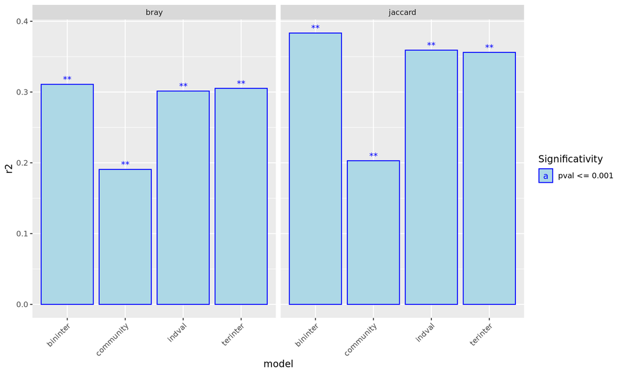

```r
#compute bray-curtis distance
video_data.bray <- vegdist(x = t(sm$X), method = "bray")

#identical(labels(video_data.bray), rownames(sm$sample_info)) # the labels in bray distance matrix and rows in metadata table in sm object are identical

# compute adonis2 on metadata with bray-curtis distance
video_data.bray.adonis2 <- adonis2(video_data.bray ~ Habitat, data = sm$sample_info, perm=999, by="terms")

# compute jaccard distance matrix
video_data.jac <- vegdist(x = t(sm$X), method = "jaccard", binary = TRUE)
#identical(labels(video_data.jac), rownames(sm$sample_info)) #same order of labels in bray distance and samples in metadata

# compute adonis2 on metadata with jaccard distance
video_data.jac.adonis2 <- adonis2(video_data.jac ~ Habitat, data = sm$sample_info, by="margin")

#compute bray-curtis distance
indval_data.bray <- vegdist(x = t(indval_data), method = "bray")

#identical(labels(indval_data.bray), rownames(sm$sample_info)) # the labels in bray distance matrix and rows in metadata table in sm object are identical

# compute adonis2 on metadata with bray-curtis distance
indval_data.bray.adonis2 <- adonis2(indval_data.bray ~ Habitat, data = sm$sample_info, perm=999, by="terms")

# compute jaccard distance matrix
indval_data.jac <- vegdist(x = t(indval_data), method = "jaccard", binary = TRUE)
#identical(labels(indval_data.jac), rownames(sm$sample_info)) #same order of labels in bray distance and samples in metadata

# compute adonis2 on metadata with jaccard distance
indval_data.jac.adonis2 <- adonis2(indval_data.jac ~ Habitat, data = sm$sample_info, by="margin")

#compute bray-curtis distance
terinter_data.bray <- vegdist(x = t(terinter_data), method = "bray")

#identical(labels(terinter_data.bray), rownames(sm$sample_info)) # the labels in bray distance matrix and rows in metadata table in sm object are identical

# compute adonis2 on metadata with bray-curtis distance
terinter_data.bray.adonis2 <- adonis2(terinter_data.bray ~ Habitat, data = sm$sample_info, perm=999, by="terms")

# compute jaccard distance matrix
terinter_data.jac <- vegdist(x = t(terinter_data), method = "jaccard", binary = TRUE)
#identical(labels(terinter_data.jac), rownames(sm$sample_info)) #same order of labels in bray distance and samples in metadata

# compute adonis2 on metadata with jaccard distance
terinter_data.jac.adonis2 <- adonis2(terinter_data.jac ~ Habitat, data = sm$sample_info, by="margin")

#compute bray-curtis distance
bininter_data.bray <- vegdist(x = t(bininter_data), method = "bray")

#identical(labels(bininter_data.bray), rownames(sm$sample_info)) # the labels in bray distance matrix and rows in metadata table in sm object are identical

# compute adonis2 on metadata with bray-curtis distance
bininter_data.bray.adonis2 <- adonis2(bininter_data.bray ~ Habitat, data = sm$sample_info, perm=999, by="terms")

# compute jaccard distance matrix
bininter_data.jac <- vegdist(x = t(bininter_data), method = "jaccard", binary = TRUE)
#identical(labels(bininter_data.jac), rownames(sm$sample_info)) #same order of labels in bray distance and samples in metadata

# compute adonis2 on metadata with jaccard distance
bininter_data.jac.adonis2 <- adonis2(bininter_data.jac ~ Habitat, data = sm$sample_info, by="margin")


permanova.list =list()

permanova.list[["bray"]][["community"]]= video_data.bray.adonis2
permanova.list[["jaccard"]][["community"]]= video_data.jac.adonis2
permanova.list[["bray"]][["indval"]]= indval_data.bray.adonis2
permanova.list[["jaccard"]][["indval"]]= indval_data.jac.adonis2
permanova.list[["bray"]][["terinter"]]= terinter_data.bray.adonis2
permanova.list[["jaccard"]][["terinter"]]= terinter_data.jac.adonis2
permanova.list[["bray"]][["bininter"]]= bininter_data.bray.adonis2
permanova.list[["jaccard"]][["bininter"]]= bininter_data.jac.adonis2

permanova.df.list= list()
## create a data frame for permanova test results
for (j in names(permanova.list)) {
  for (k in c("community", "indval", "terinter", "bininter")) {
    result= permanova.list[[j]][[k]]
    permanova.df <- data.frame(result$R2)
    colnames(permanova.df) <- c("r2")
    permanova.df$var <- rownames(result)
    permanova.df$p.val <- result$`Pr(>F)`

    ## remove residual and total from the data frame
    permanova.df <- permanova.df[!(permanova.df$var) %in% c('Residual','Total'),]
    permanova.df$model <- k
    permanova.df$distance <- j

    ## save dataframes in the list

  permanova.df.list[[j]][[k]] = permanova.df
  }
}

#For each element in permanova.df.list, do the rbind of the dataframes of each binary prediction task
permanova.df.list <- lapply(permanova.df.list, function(x){do.call("rbind", x)})

#merge individual dataframes in single dataframe
permanova.df <- do.call("rbind",permanova.df.list)

permanova.df$colour <- ifelse(permanova.df$p.val<=0.001,"blue","red")

ggplot(data=permanova.df, aes(x=model, y=r2, color=colour)) +
  geom_bar(stat="identity", fill="lightblue")+
  geom_text(aes(label=ifelse(p.val <= 0.001, "**" , ifelse(p.val <= 0.05, "*" , " " ))), vjust=-0.3, size=3.5,nudge_y=-0.0003)+ theme(axis.text.x = element_text(angle = 45, hjust = 1))+
  scale_color_manual(values = c('blue', 'red'), labels =  c( 'pval <= 0.001', 'pval > 0.001 & pval <=0.05')) +
  labs(color = "Significativity") +
  facet_grid(.~distance)
```

## Abundance of predomics indicator species on Habitat

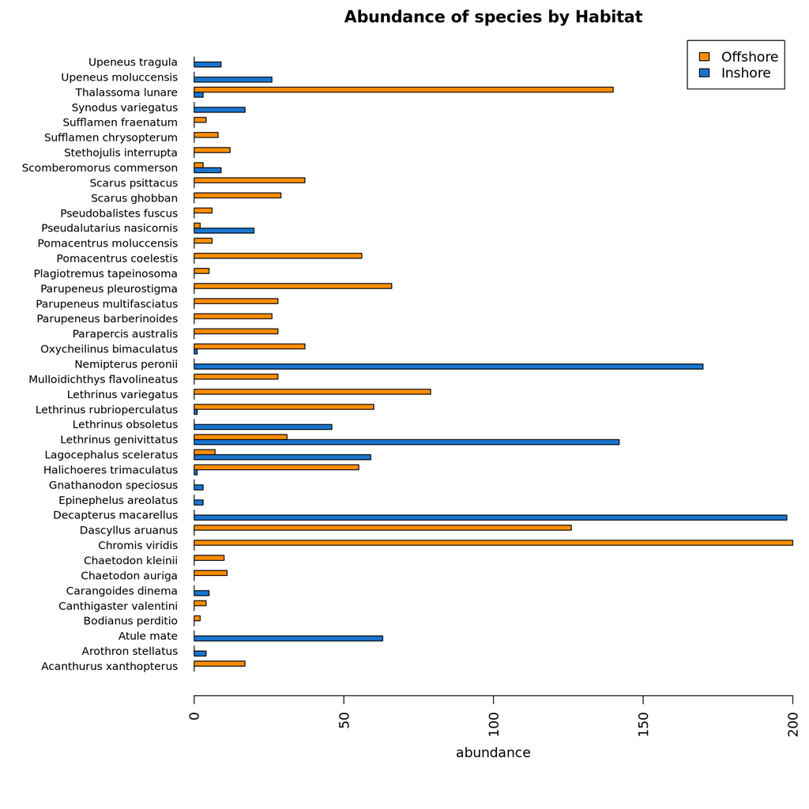

```r
# combine terinter and bininter species
pred_spec.df = merge(df2, df3, by= "Species", all = TRUE)

pred_spec.df = filter(pred_spec.df, IsInFBM.x == 1 | IsInFBM.y == 1)

pred_spec.abund = sm$sample_info[, 3:153]
pred_spec.abund= pred_spec.abund %>% select(-c(hab, Spygen))
pred_spec.abund= ddply(pred_spec.abund, "Habitat", numcolwise(sum))
row.names(pred_spec.abund)= pred_spec.abund$Habitat
pred_spec.abund= t(pred_spec.abund %>% select(-c(Habitat)))
pred_spec.abund=pred_spec.abund[which(rownames(pred_spec.abund) %in% pred_spec.df$Species),]

# pred_spec.abund = as.data.frame(pred_spec.abund)
# pred_spec.abund$species= rownames(pred_spec.abund)
# Increase margin size
par(mar=c(7,12,2,1))

#barplot(pred_spec.abund)
barplot(t(pred_spec.abund), beside=TRUE, col=c("dodgerblue3", "darkorange"), las=2,
        main = "Abundance of species by Habitat", horiz = TRUE,
      legend.text = colnames(pred_spec.abund),
        cex.names = 0.8,
        xlab= "abundance",
        xlim=range(pretty(c(0, pred_spec.abund*1))))
```